# 진현지_2231162_MidTerm_Project

## [DA] E-Commerce Data Analysis

```python
pip install wget
```

```python
import wget

# 데이터 파일 다운로드
url = "http://vsq.kr/smwu_DS/DATA/E-Commerce.data.utf8.csv"

wget.download(url)
```

```
 58% [..........................................                              ] 26689536 / 45580606100% [........................................................................] 45580606 / 45580606
```

```
'E-Commerce.data.utf8.csv'
```

```python
%matplotlib inline
import numpy as np
import pandas as pd
import matplotlib.pyplot as plt
import seaborn as sns
sns.set()

plt.rcParams['font.family'] = ['NanumBarunGothic', 'Malgun Gothic', 'AppleGothic']  # 한글 출력을 위한 글꼴 설정
plt.rcParams['axes.unicode_minus'] = False    # 문자 - (마이너스) 정상 출력을 위한 코드
```

- InvoiceNo 주문
- StockCode 물품 정보

## 데이터 불러오기

```python
rawdata_df = pd.read_csv('./E-Commerce.data.utf8.csv')
```

```python
rawdata_df
```

|  | InvoiceNo | StockCode | Description | Quantity | InvoiceDate | UnitPrice | CustomerID | Country |
| --- | --- | --- | --- | --- | --- | --- | --- | --- |
| 0 | 536365 | 85123A | WHITE HANGING HEART T-LIGHT HOLDER | 6 | 12/1/2010 8:26 | 2.55 | 17850.0 | United Kingdom |
| 1 | 536365 | 71053 | WHITE METAL LANTERN | 6 | 12/1/2010 8:26 | 3.39 | 17850.0 | United Kingdom |
| 2 | 536365 | 84406B | CREAM CUPID HEARTS COAT HANGER | 8 | 12/1/2010 8:26 | 2.75 | 17850.0 | United Kingdom |
| 3 | 536365 | 84029G | KNITTED UNION FLAG HOT WATER BOTTLE | 6 | 12/1/2010 8:26 | 3.39 | 17850.0 | United Kingdom |
| 4 | 536365 | 84029E | RED WOOLLY HOTTIE WHITE HEART. | 6 | 12/1/2010 8:26 | 3.39 | 17850.0 | United Kingdom |
| ... | ... | ... | ... | ... | ... | ... | ... | ... |
| 541904 | 581587 | 22613 | PACK OF 20 SPACEBOY NAPKINS | 12 | 12/9/2011 12:50 | 0.85 | 12680.0 | France |
| 541905 | 581587 | 22899 | CHILDREN'S APRON DOLLY GIRL | 6 | 12/9/2011 12:50 | 2.10 | 12680.0 | France |
| 541906 | 581587 | 23254 | CHILDRENS CUTLERY DOLLY GIRL | 4 | 12/9/2011 12:50 | 4.15 | 12680.0 | France |
| 541907 | 581587 | 23255 | CHILDRENS CUTLERY CIRCUS PARADE | 4 | 12/9/2011 12:50 | 4.15 | 12680.0 | France |
| 541908 | 581587 | 22138 | BAKING SET 9 PIECE RETROSPOT | 3 | 12/9/2011 12:50 | 4.95 | 12680.0 | France |

541909 rows × 8 columns

## 데이터 전처리

각 row별로 개당단가 `UnitPrice`와 주문수량 `Quantity`가 있습니다. row의 총 주문금액이 있으면 유용할 것 같습니다.  
두 값들을 곱해 전체 주문금액인 `TrAmount`를 만들어 봅시다

```python
rawdata_df['TrAmount'] = rawdata_df['Quantity'] * rawdata_df['UnitPrice']
```

```python
rawdata_df.head()
```

|  | InvoiceNo | StockCode | Description | Quantity | InvoiceDate | UnitPrice | CustomerID | Country | TrAmount |
| --- | --- | --- | --- | --- | --- | --- | --- | --- | --- |
| 0 | 536365 | 85123A | WHITE HANGING HEART T-LIGHT HOLDER | 6 | 12/1/2010 8:26 | 2.55 | 17850.0 | United Kingdom | 15.30 |
| 1 | 536365 | 71053 | WHITE METAL LANTERN | 6 | 12/1/2010 8:26 | 3.39 | 17850.0 | United Kingdom | 20.34 |
| 2 | 536365 | 84406B | CREAM CUPID HEARTS COAT HANGER | 8 | 12/1/2010 8:26 | 2.75 | 17850.0 | United Kingdom | 22.00 |
| 3 | 536365 | 84029G | KNITTED UNION FLAG HOT WATER BOTTLE | 6 | 12/1/2010 8:26 | 3.39 | 17850.0 | United Kingdom | 20.34 |
| 4 | 536365 | 84029E | RED WOOLLY HOTTIE WHITE HEART. | 6 | 12/1/2010 8:26 | 3.39 | 17850.0 | United Kingdom | 20.34 |

TrAmount가 0인 row는 무엇인가 잘못된 데이터일 가능성이 큽니다.  
따라서 이 데이터들을 `.drop()`으로 제거해주겠습니다.

```python
rawdata_df.query('TrAmount == 0')
```

|  | InvoiceNo | StockCode | Description | Quantity | InvoiceDate | UnitPrice | CustomerID | Country | TrAmount |
| --- | --- | --- | --- | --- | --- | --- | --- | --- | --- |
| 622 | 536414 | 22139 | NaN | 56 | 12/1/2010 11:52 | 0.0 | NaN | United Kingdom | 0.0 |
| 1970 | 536545 | 21134 | NaN | 1 | 12/1/2010 14:32 | 0.0 | NaN | United Kingdom | 0.0 |
| 1971 | 536546 | 22145 | NaN | 1 | 12/1/2010 14:33 | 0.0 | NaN | United Kingdom | 0.0 |
| 1972 | 536547 | 37509 | NaN | 1 | 12/1/2010 14:33 | 0.0 | NaN | United Kingdom | 0.0 |
| 1987 | 536549 | 85226A | NaN | 1 | 12/1/2010 14:34 | 0.0 | NaN | United Kingdom | 0.0 |
| ... | ... | ... | ... | ... | ... | ... | ... | ... | ... |
| 536981 | 581234 | 72817 | NaN | 27 | 12/8/2011 10:33 | 0.0 | NaN | United Kingdom | 0.0 |
| 538504 | 581406 | 46000M | POLYESTER FILLER PAD 45x45cm | 240 | 12/8/2011 13:58 | 0.0 | NaN | United Kingdom | 0.0 |
| 538505 | 581406 | 46000S | POLYESTER FILLER PAD 40x40cm | 300 | 12/8/2011 13:58 | 0.0 | NaN | United Kingdom | 0.0 |
| 538554 | 581408 | 85175 | NaN | 20 | 12/8/2011 14:06 | 0.0 | NaN | United Kingdom | 0.0 |
| 538919 | 581422 | 23169 | smashed | -235 | 12/8/2011 15:24 | 0.0 | NaN | United Kingdom | -0.0 |

2515 rows × 9 columns

약 54만 row 중, TrAmount가 0인 row는 2515개입니다.  
차지하는 비중이 크지 않으므로, 삭제하여도 무방할 것 같습니다.

```python
zero_amount_indexes = rawdata_df.query('TrAmount == 0').index
zero_amount_indexes
```

```
Int64Index([   622,   1970,   1971,   1972,   1987,   1988,   2024,   2025,
              2026,   2406,
            ...
            535333, 535334, 535335, 535336, 536908, 536981, 538504, 538505,
            538554, 538919],
           dtype='int64', length=2515)
```

```python
ecmm_df = rawdata_df.drop(index=zero_amount_indexes)
```

```python
ecmm_df
```

|  | InvoiceNo | StockCode | Description | Quantity | InvoiceDate | UnitPrice | CustomerID | Country | TrAmount |
| --- | --- | --- | --- | --- | --- | --- | --- | --- | --- |
| 0 | 536365 | 85123A | WHITE HANGING HEART T-LIGHT HOLDER | 6 | 12/1/2010 8:26 | 2.55 | 17850.0 | United Kingdom | 15.30 |
| 1 | 536365 | 71053 | WHITE METAL LANTERN | 6 | 12/1/2010 8:26 | 3.39 | 17850.0 | United Kingdom | 20.34 |
| 2 | 536365 | 84406B | CREAM CUPID HEARTS COAT HANGER | 8 | 12/1/2010 8:26 | 2.75 | 17850.0 | United Kingdom | 22.00 |
| 3 | 536365 | 84029G | KNITTED UNION FLAG HOT WATER BOTTLE | 6 | 12/1/2010 8:26 | 3.39 | 17850.0 | United Kingdom | 20.34 |
| 4 | 536365 | 84029E | RED WOOLLY HOTTIE WHITE HEART. | 6 | 12/1/2010 8:26 | 3.39 | 17850.0 | United Kingdom | 20.34 |
| ... | ... | ... | ... | ... | ... | ... | ... | ... | ... |
| 541904 | 581587 | 22613 | PACK OF 20 SPACEBOY NAPKINS | 12 | 12/9/2011 12:50 | 0.85 | 12680.0 | France | 10.20 |
| 541905 | 581587 | 22899 | CHILDREN'S APRON DOLLY GIRL | 6 | 12/9/2011 12:50 | 2.10 | 12680.0 | France | 12.60 |
| 541906 | 581587 | 23254 | CHILDRENS CUTLERY DOLLY GIRL | 4 | 12/9/2011 12:50 | 4.15 | 12680.0 | France | 16.60 |
| 541907 | 581587 | 23255 | CHILDRENS CUTLERY CIRCUS PARADE | 4 | 12/9/2011 12:50 | 4.15 | 12680.0 | France | 16.60 |
| 541908 | 581587 | 22138 | BAKING SET 9 PIECE RETROSPOT | 3 | 12/9/2011 12:50 | 4.95 | 12680.0 | France | 14.85 |

539394 rows × 9 columns

```python
ecmm_df.info()
```

```
<class 'pandas.core.frame.DataFrame'>
Int64Index: 539394 entries, 0 to 541908
Data columns (total 9 columns):
 #   Column       Non-Null Count   Dtype
---  ------       --------------   -----
 0   InvoiceNo    539394 non-null  object
 1   StockCode    539394 non-null  object
 2   Description  539394 non-null  object
 3   Quantity     539394 non-null  int64
 4   InvoiceDate  539394 non-null  object
 5   UnitPrice    539394 non-null  float64
 6   CustomerID   406789 non-null  float64
 7   Country      539394 non-null  object
 8   TrAmount     539394 non-null  float64
dtypes: float64(3), int64(1), object(5)
memory usage: 41.2+ MB
```

CustomerID에도 NaN 값이 있네요. 우선 어떤 데이터들인지 한번 확인해봅시다.

```python
ecmm_df.CustomerID.isna().value_counts()
```

```
False    406789
True     132605
Name: CustomerID, dtype: int64
```

```python
ecmm_df[ecmm_df.CustomerID.isna()]
```

|  | InvoiceNo | StockCode | Description | Quantity | InvoiceDate | UnitPrice | CustomerID | Country | TrAmount |
| --- | --- | --- | --- | --- | --- | --- | --- | --- | --- |
| 1443 | 536544 | 21773 | DECORATIVE ROSE BATHROOM BOTTLE | 1 | 12/1/2010 14:32 | 2.51 | NaN | United Kingdom | 2.51 |
| 1444 | 536544 | 21774 | DECORATIVE CATS BATHROOM BOTTLE | 2 | 12/1/2010 14:32 | 2.51 | NaN | United Kingdom | 5.02 |
| 1445 | 536544 | 21786 | POLKADOT RAIN HAT | 4 | 12/1/2010 14:32 | 0.85 | NaN | United Kingdom | 3.40 |
| 1446 | 536544 | 21787 | RAIN PONCHO RETROSPOT | 2 | 12/1/2010 14:32 | 1.66 | NaN | United Kingdom | 3.32 |
| 1447 | 536544 | 21790 | VINTAGE SNAP CARDS | 9 | 12/1/2010 14:32 | 1.66 | NaN | United Kingdom | 14.94 |
| ... | ... | ... | ... | ... | ... | ... | ... | ... | ... |
| 541536 | 581498 | 85099B | JUMBO BAG RED RETROSPOT | 5 | 12/9/2011 10:26 | 4.13 | NaN | United Kingdom | 20.65 |
| 541537 | 581498 | 85099C | JUMBO BAG BAROQUE BLACK WHITE | 4 | 12/9/2011 10:26 | 4.13 | NaN | United Kingdom | 16.52 |
| 541538 | 581498 | 85150 | LADIES & GENTLEMEN METAL SIGN | 1 | 12/9/2011 10:26 | 4.96 | NaN | United Kingdom | 4.96 |
| 541539 | 581498 | 85174 | S/4 CACTI CANDLES | 1 | 12/9/2011 10:26 | 10.79 | NaN | United Kingdom | 10.79 |
| 541540 | 581498 | DOT | DOTCOM POSTAGE | 1 | 12/9/2011 10:26 | 1714.17 | NaN | United Kingdom | 1714.17 |

132605 rows × 9 columns

갯수가 13만개이면 상당한 비중을 차지합니다. 따라서 빈 CustomerID에 대해 특정 값을 임의로 넣어주겠습니다.

```python
customerid_nan_indexes = ecmm_df[ecmm_df.CustomerID.isna()].index
customerid_nan_indexes
```

```
Int64Index([  1443,   1444,   1445,   1446,   1447,   1448,   1449,   1450,
              1451,   1452,
            ...
            541531, 541532, 541533, 541534, 541535, 541536, 541537, 541538,
            541539, 541540],
           dtype='int64', length=132605)
```

```python
ecmm_df.loc[customerid_nan_indexes, 'CustomerID'] = '%EMPTY%'
```

```python
ecmm_df.info()
```

```
<class 'pandas.core.frame.DataFrame'>
Int64Index: 539394 entries, 0 to 541908
Data columns (total 9 columns):
 #   Column       Non-Null Count   Dtype
---  ------       --------------   -----
 0   InvoiceNo    539394 non-null  object
 1   StockCode    539394 non-null  object
 2   Description  539394 non-null  object
 3   Quantity     539394 non-null  int64
 4   InvoiceDate  539394 non-null  object
 5   UnitPrice    539394 non-null  float64
 6   CustomerID   539394 non-null  object
 7   Country      539394 non-null  object
 8   TrAmount     539394 non-null  float64
dtypes: float64(2), int64(1), object(6)
memory usage: 57.3+ MB
```

모든 행에서 NaN 값이 발견되지 않았습니다.

```python
ecmm_df.InvoiceDate
```

```
0          12/1/2010 8:26
1          12/1/2010 8:26
2          12/1/2010 8:26
3          12/1/2010 8:26
4          12/1/2010 8:26
               ...
541904    12/9/2011 12:50
541905    12/9/2011 12:50
541906    12/9/2011 12:50
541907    12/9/2011 12:50
541908    12/9/2011 12:50
Name: InvoiceDate, Length: 539394, dtype: object
```

주문시각 InvoiceDate가 Datetime 형식이 아닙니다  
`pd.to_datetime()`를 이용해 표준 Datetime 형태로 바꾸고, 날짜만을 따로 빼서 새 컬럼에 할당해봅시다

```python
pd.to_datetime(ecmm_df.InvoiceDate)
```

```
0        2010-12-01 08:26:00
1        2010-12-01 08:26:00
2        2010-12-01 08:26:00
3        2010-12-01 08:26:00
4        2010-12-01 08:26:00
                 ...
541904   2011-12-09 12:50:00
541905   2011-12-09 12:50:00
541906   2011-12-09 12:50:00
541907   2011-12-09 12:50:00
541908   2011-12-09 12:50:00
Name: InvoiceDate, Length: 539394, dtype: datetime64[ns]
```

```python
ecmm_df.loc[:,'InvoiceDatetime'] = pd.to_datetime(ecmm_df.InvoiceDate)
```

```python
ecmm_df.InvoiceDatetime
```

```
0        2010-12-01 08:26:00
1        2010-12-01 08:26:00
2        2010-12-01 08:26:00
3        2010-12-01 08:26:00
4        2010-12-01 08:26:00
                 ...
541904   2011-12-09 12:50:00
541905   2011-12-09 12:50:00
541906   2011-12-09 12:50:00
541907   2011-12-09 12:50:00
541908   2011-12-09 12:50:00
Name: InvoiceDatetime, Length: 539394, dtype: datetime64[ns]
```

표준 형태로 바뀐 Datetime 컬럼에서 `.dt.date`를 통해 날짜만 접근할 수 있습니다.

```python
ecmm_df.InvoiceDatetime.dt.date
```

```
0         2010-12-01
1         2010-12-01
2         2010-12-01
3         2010-12-01
4         2010-12-01
             ...
541904    2011-12-09
541905    2011-12-09
541906    2011-12-09
541907    2011-12-09
541908    2011-12-09
Name: InvoiceDatetime, Length: 539394, dtype: object
```

```python
ecmm_df.InvoiceDatetime.dt.year
```

```
0         2010
1         2010
2         2010
3         2010
4         2010
          ...
541904    2011
541905    2011
541906    2011
541907    2011
541908    2011
Name: InvoiceDatetime, Length: 539394, dtype: int64
```

```python
ecmm_df.InvoiceDatetime.dt.month
```

```
0         12
1         12
2         12
3         12
4         12
          ..
541904    12
541905    12
541906    12
541907    12
541908    12
Name: InvoiceDatetime, Length: 539394, dtype: int64
```

```python
ecmm_df.loc[:,'InvoiceDate'] = ecmm_df.InvoiceDatetime.dt.date
```

```python
ecmm_df.describe()
```

|  | Quantity | UnitPrice | TrAmount |
| --- | --- | --- | --- |
| count | 539394.000000 | 539394.000000 | 539394.000000 |
| mean | 9.845871 | 4.632614 | 18.071665 |
| std | 215.412253 | 96.984656 | 379.690931 |
| min | -80995.000000 | -11062.060000 | -168469.600000 |
| 25% | 1.000000 | 1.250000 | 3.750000 |
| 50% | 3.000000 | 2.080000 | 9.840000 |
| 75% | 10.000000 | 4.130000 | 17.400000 |
| max | 80995.000000 | 38970.000000 | 168469.600000 |

년월, 월, 요일, 시간도 추가해봅시다.

```python
ecmm_df.loc[:, 'year_month'] = ecmm_df.InvoiceDatetime.dt.year * 100 + ecmm_df.InvoiceDatetime.dt.month
```

```python
ecmm_df.info()
```

```
<class 'pandas.core.frame.DataFrame'>
Int64Index: 539394 entries, 0 to 541908
Data columns (total 11 columns):
 #   Column           Non-Null Count   Dtype
---  ------           --------------   -----
 0   InvoiceNo        539394 non-null  object
 1   StockCode        539394 non-null  object
 2   Description      539394 non-null  object
 3   Quantity         539394 non-null  int64
 4   InvoiceDate      539394 non-null  object
 5   UnitPrice        539394 non-null  float64
 6   CustomerID       539394 non-null  object
 7   Country          539394 non-null  object
 8   TrAmount         539394 non-null  float64
 9   InvoiceDatetime  539394 non-null  datetime64[ns]
 10  year_month       539394 non-null  int64
dtypes: datetime64[ns](1), float64(2), int64(2), object(6)
memory usage: 65.5+ MB
```

```python
ecmm_df.loc[:, 'month'] = ecmm_df.InvoiceDatetime.dt.month
```

```python
ecmm_df.loc[:, 'day'] = ecmm_df.InvoiceDatetime.dt.dayofweek + 1  # dayofweek 월요일1 ~ 일요일7
```

```python
ecmm_df.loc[:, 'hour'] = ecmm_df.InvoiceDatetime.dt.hour
```

```python
ecmm_df
```

|  | InvoiceNo | StockCode | Description | Quantity | InvoiceDate | UnitPrice | CustomerID | Country | TrAmount | InvoiceDatetime | year_month | month | day | hour |
| --- | --- | --- | --- | --- | --- | --- | --- | --- | --- | --- | --- | --- | --- | --- |
| 0 | 536365 | 85123A | WHITE HANGING HEART T-LIGHT HOLDER | 6 | 2010-12-01 | 2.55 | 17850.0 | United Kingdom | 15.30 | 2010-12-01 08:26:00 | 201012 | 12 | 3 | 8 |
| 1 | 536365 | 71053 | WHITE METAL LANTERN | 6 | 2010-12-01 | 3.39 | 17850.0 | United Kingdom | 20.34 | 2010-12-01 08:26:00 | 201012 | 12 | 3 | 8 |
| 2 | 536365 | 84406B | CREAM CUPID HEARTS COAT HANGER | 8 | 2010-12-01 | 2.75 | 17850.0 | United Kingdom | 22.00 | 2010-12-01 08:26:00 | 201012 | 12 | 3 | 8 |
| 3 | 536365 | 84029G | KNITTED UNION FLAG HOT WATER BOTTLE | 6 | 2010-12-01 | 3.39 | 17850.0 | United Kingdom | 20.34 | 2010-12-01 08:26:00 | 201012 | 12 | 3 | 8 |
| 4 | 536365 | 84029E | RED WOOLLY HOTTIE WHITE HEART. | 6 | 2010-12-01 | 3.39 | 17850.0 | United Kingdom | 20.34 | 2010-12-01 08:26:00 | 201012 | 12 | 3 | 8 |
| ... | ... | ... | ... | ... | ... | ... | ... | ... | ... | ... | ... | ... | ... | ... |
| 541904 | 581587 | 22613 | PACK OF 20 SPACEBOY NAPKINS | 12 | 2011-12-09 | 0.85 | 12680.0 | France | 10.20 | 2011-12-09 12:50:00 | 201112 | 12 | 5 | 12 |
| 541905 | 581587 | 22899 | CHILDREN'S APRON DOLLY GIRL | 6 | 2011-12-09 | 2.10 | 12680.0 | France | 12.60 | 2011-12-09 12:50:00 | 201112 | 12 | 5 | 12 |
| 541906 | 581587 | 23254 | CHILDRENS CUTLERY DOLLY GIRL | 4 | 2011-12-09 | 4.15 | 12680.0 | France | 16.60 | 2011-12-09 12:50:00 | 201112 | 12 | 5 | 12 |
| 541907 | 581587 | 23255 | CHILDRENS CUTLERY CIRCUS PARADE | 4 | 2011-12-09 | 4.15 | 12680.0 | France | 16.60 | 2011-12-09 12:50:00 | 201112 | 12 | 5 | 12 |
| 541908 | 581587 | 22138 | BAKING SET 9 PIECE RETROSPOT | 3 | 2011-12-09 | 4.95 | 12680.0 | France | 14.85 | 2011-12-09 12:50:00 | 201112 | 12 | 5 | 12 |

539394 rows × 14 columns

Quantity와 UnitPrice, TrAmount가 음수인 경우가 있습니다. 이 데이터들을 한번 살펴보겠습니다.

```python
ecmm_df.query("Quantity < 0")
```

|  | InvoiceNo | StockCode | Description | Quantity | InvoiceDate | UnitPrice | CustomerID | Country | TrAmount | InvoiceDatetime | year_month | month | day | hour |
| --- | --- | --- | --- | --- | --- | --- | --- | --- | --- | --- | --- | --- | --- | --- |
| 141 | C536379 | D | Discount | -1 | 2010-12-01 | 27.50 | 14527.0 | United Kingdom | -27.50 | 2010-12-01 09:41:00 | 201012 | 12 | 3 | 9 |
| 154 | C536383 | 35004C | SET OF 3 COLOURED FLYING DUCKS | -1 | 2010-12-01 | 4.65 | 15311.0 | United Kingdom | -4.65 | 2010-12-01 09:49:00 | 201012 | 12 | 3 | 9 |
| 235 | C536391 | 22556 | PLASTERS IN TIN CIRCUS PARADE | -12 | 2010-12-01 | 1.65 | 17548.0 | United Kingdom | -19.80 | 2010-12-01 10:24:00 | 201012 | 12 | 3 | 10 |
| 236 | C536391 | 21984 | PACK OF 12 PINK PAISLEY TISSUES | -24 | 2010-12-01 | 0.29 | 17548.0 | United Kingdom | -6.96 | 2010-12-01 10:24:00 | 201012 | 12 | 3 | 10 |
| 237 | C536391 | 21983 | PACK OF 12 BLUE PAISLEY TISSUES | -24 | 2010-12-01 | 0.29 | 17548.0 | United Kingdom | -6.96 | 2010-12-01 10:24:00 | 201012 | 12 | 3 | 10 |
| ... | ... | ... | ... | ... | ... | ... | ... | ... | ... | ... | ... | ... | ... | ... |
| 540449 | C581490 | 23144 | ZINC T-LIGHT HOLDER STARS SMALL | -11 | 2011-12-09 | 0.83 | 14397.0 | United Kingdom | -9.13 | 2011-12-09 09:57:00 | 201112 | 12 | 5 | 9 |
| 541541 | C581499 | M | Manual | -1 | 2011-12-09 | 224.69 | 15498.0 | United Kingdom | -224.69 | 2011-12-09 10:28:00 | 201112 | 12 | 5 | 10 |
| 541715 | C581568 | 21258 | VICTORIAN SEWING BOX LARGE | -5 | 2011-12-09 | 10.95 | 15311.0 | United Kingdom | -54.75 | 2011-12-09 11:57:00 | 201112 | 12 | 5 | 11 |
| 541716 | C581569 | 84978 | HANGING HEART JAR T-LIGHT HOLDER | -1 | 2011-12-09 | 1.25 | 17315.0 | United Kingdom | -1.25 | 2011-12-09 11:58:00 | 201112 | 12 | 5 | 11 |
| 541717 | C581569 | 20979 | 36 PENCILS TUBE RED RETROSPOT | -5 | 2011-12-09 | 1.25 | 17315.0 | United Kingdom | -6.25 | 2011-12-09 11:58:00 | 201112 | 12 | 5 | 11 |

9288 rows × 14 columns

```python
ecmm_df.query("Quantity < 0").InvoiceNo.str[0]
```

```
141       C
154       C
235       C
236       C
237       C
         ..
540449    C
541541    C
541715    C
541716    C
541717    C
Name: InvoiceNo, Length: 9288, dtype: object
```

```python
ecmm_df.query('UnitPrice < 0')
```

|  | InvoiceNo | StockCode | Description | Quantity | InvoiceDate | UnitPrice | CustomerID | Country | TrAmount | InvoiceDatetime | year_month | month | day | hour |
| --- | --- | --- | --- | --- | --- | --- | --- | --- | --- | --- | --- | --- | --- | --- |
| 299983 | A563186 | B | Adjust bad debt | 1 | 2011-08-12 | -11062.06 | %EMPTY% | United Kingdom | -11062.06 | 2011-08-12 14:51:00 | 201108 | 8 | 5 | 14 |
| 299984 | A563187 | B | Adjust bad debt | 1 | 2011-08-12 | -11062.06 | %EMPTY% | United Kingdom | -11062.06 | 2011-08-12 14:52:00 | 201108 | 8 | 5 | 14 |

UnitPrice가 0미만인 경우는 확실히 잘못된 데이터 같습니다  
Quantity가 0 미만인 것은 `C`로 시작하는 InvoiceNo를 미루어볼 때, 반품 건인 것 같습니다  
첫 경우는 제외하고 반품 건은 새로운 데이터 프레임으로 만들겠습니다.

```python
minus_indexes = ecmm_df.query('UnitPrice < 0').index
minus_indexes
```

```
Int64Index([299983, 299984], dtype='int64')
```

```python
ecmm_df = ecmm_df.drop(index=minus_indexes)
```

```python
ecmm_df = ecmm_df.set_index("StockCode").sort_index(ascending =False)
ecmm_df[:200]
```

| StockCode | InvoiceNo | Description | Quantity | InvoiceDate | UnitPrice | CustomerID | Country | TrAmount | InvoiceDatetime | year_month | month | day | hour |
| --- | --- | --- | --- | --- | --- | --- | --- | --- | --- | --- | --- | --- | --- |
| m | 539736 | Manual | 1 | 2010-12-21 | 2.55 | %EMPTY% | United Kingdom | 2.55 | 2010-12-21 15:18:00 | 201012 | 12 | 2 | 15 |
| gift_0001_50 | 558066 | Dotcomgiftshop Gift Voucher ?0.00 | 1 | 2011-06-24 | 41.67 | %EMPTY% | United Kingdom | 41.67 | 2011-06-24 15:45:00 | 201106 | 6 | 5 | 15 |
| gift_0001_50 | 552232 | Dotcomgiftshop Gift Voucher ?0.00 | 1 | 2011-05-06 | 41.67 | %EMPTY% | United Kingdom | 41.67 | 2011-05-06 15:54:00 | 201105 | 5 | 5 | 15 |
| gift_0001_50 | 558614 | Dotcomgiftshop Gift Voucher ?0.00 | 1 | 2011-06-30 | 41.67 | %EMPTY% | United Kingdom | 41.67 | 2011-06-30 15:56:00 | 201106 | 6 | 4 | 15 |
| gift_0001_50 | 539958 | Dotcomgiftshop Gift Voucher ?0.00 | 1 | 2010-12-23 | 42.55 | %EMPTY% | United Kingdom | 42.55 | 2010-12-23 13:26:00 | 201012 | 12 | 4 | 13 |
| ... | ... | ... | ... | ... | ... | ... | ... | ... | ... | ... | ... | ... | ... |
| POST | 539636 | POSTAGE | 6 | 2010-12-20 | 18.00 | 12481.0 | Germany | 108.00 | 2010-12-20 15:15:00 | 201012 | 12 | 1 | 15 |
| POST | 569017 | POSTAGE | 2 | 2011-09-30 | 18.00 | 13813.0 | Germany | 36.00 | 2011-09-30 09:22:00 | 201109 | 9 | 5 | 9 |
| POST | 569018 | POSTAGE | 1 | 2011-09-30 | 40.00 | 12676.0 | Sweden | 40.00 | 2011-09-30 09:25:00 | 201109 | 9 | 5 | 9 |
| POST | 569033 | POSTAGE | 1 | 2011-09-30 | 6.00 | 15611.0 | United Kingdom | 6.00 | 2011-09-30 10:40:00 | 201109 | 9 | 5 | 10 |
| POST | 560635 | POSTAGE | 3 | 2011-07-20 | 18.00 | 12521.0 | Germany | 54.00 | 2011-07-20 10:51:00 | 201107 | 7 | 3 | 10 |

200 rows × 13 columns

상품이 아닌 항목들을 제거하도록 하겠습니다.

```python
ecmm_df = ecmm_df.drop(["m","POST","M","gift_0001_50","gift_0001_40","DOT","gift_0001_30","gift_0001_20","gift_0001_10","S","D","CRUK","C2","BANK CHARGES","B","AMAZONFEE"])
ecmm_df = ecmm_df.reset_index()
```

```python
returned_df = ecmm_df.query("Quantity < 0")
returned_df
```

|  | StockCode | InvoiceNo | Description | Quantity | InvoiceDate | UnitPrice | CustomerID | Country | TrAmount | InvoiceDatetime | year_month | month | day | hour |
| --- | --- | --- | --- | --- | --- | --- | --- | --- | --- | --- | --- | --- | --- | --- |
| 618 | 90211B | C539602 | JET BLACK LAS VEGAS NECKLACE 45CM | -2 | 2010-12-20 | 5.95 | 13369.0 | United Kingdom | -11.90 | 2010-12-20 14:02:00 | 201012 | 12 | 1 | 14 |
| 677 | 90209C | C570828 | PINK ENAMEL+GLASS HAIR COMB | -3 | 2011-10-12 | 2.10 | 14911.0 | EIRE | -6.30 | 2011-10-12 13:15:00 | 201110 | 10 | 3 | 13 |
| 752 | 90209A | C570828 | PURPLE ENAMEL+GLASS HAIR COMB | -6 | 2011-10-12 | 2.10 | 14911.0 | EIRE | -12.60 | 2011-10-12 13:15:00 | 201110 | 10 | 3 | 13 |
| 756 | 90208 | C570828 | PAIR OF PINK FLOWER CLUSTER SLIDE | -6 | 2011-10-12 | 2.55 | 14911.0 | EIRE | -15.30 | 2011-10-12 13:15:00 | 201110 | 10 | 3 | 13 |
| 874 | 90204 | C570828 | PAIR OF ENAMEL BUTTERFLY HAIRCLIP | -4 | 2011-10-12 | 3.35 | 14911.0 | EIRE | -13.40 | 2011-10-12 13:15:00 | 201110 | 10 | 3 | 13 |
| ... | ... | ... | ... | ... | ... | ... | ... | ... | ... | ... | ... | ... | ... | ... |
| 535794 | 11001 | C568412 | ASSTD DESIGN RACING CAR PEN | -1 | 2011-09-27 | 1.69 | 14456.0 | United Kingdom | -1.69 | 2011-09-27 10:54:00 | 201109 | 9 | 2 | 10 |
| 535799 | 11001 | C565044 | ASSTD DESIGN RACING CAR PEN | -180 | 2011-08-31 | 1.27 | 12931.0 | United Kingdom | -228.60 | 2011-08-31 17:02:00 | 201108 | 8 | 3 | 17 |
| 535834 | 11001 | C537043 | ASSTD DESIGN RACING CAR PEN | -1 | 2010-12-05 | 1.69 | 15351.0 | United Kingdom | -1.69 | 2010-12-05 10:48:00 | 201012 | 12 | 7 | 10 |
| 535905 | 10135 | C571707 | COLOURING PENCILS BROWN TUBE | -1 | 2011-10-18 | 1.25 | 14056.0 | United Kingdom | -1.25 | 2011-10-18 15:33:00 | 201110 | 10 | 2 | 15 |
| 536165 | 10133 | C558716 | COLOURING PENCILS BROWN TUBE | -10 | 2011-07-01 | 0.42 | 17888.0 | United Kingdom | -4.20 | 2011-07-01 13:22:00 | 201107 | 7 | 5 | 13 |

8704 rows × 14 columns

## Q1. 반품 건에 대한 종합적인 분석을 수행해보세요.

(반품이 많은 상품, 특정 시기, 나라 별 특징 등) 그리고 어떠한 패턴/특징이 있는지 찾아내고, 반품을 줄일 수 있는 제안을 만들어보세요.

```python
returned_df
```

|  | StockCode | InvoiceNo | Description | Quantity | InvoiceDate | UnitPrice | CustomerID | Country | TrAmount | InvoiceDatetime | year_month | month | day | hour |
| --- | --- | --- | --- | --- | --- | --- | --- | --- | --- | --- | --- | --- | --- | --- |
| 618 | 90211B | C539602 | JET BLACK LAS VEGAS NECKLACE 45CM | -2 | 2010-12-20 | 5.95 | 13369.0 | United Kingdom | -11.90 | 2010-12-20 14:02:00 | 201012 | 12 | 1 | 14 |
| 677 | 90209C | C570828 | PINK ENAMEL+GLASS HAIR COMB | -3 | 2011-10-12 | 2.10 | 14911.0 | EIRE | -6.30 | 2011-10-12 13:15:00 | 201110 | 10 | 3 | 13 |
| 752 | 90209A | C570828 | PURPLE ENAMEL+GLASS HAIR COMB | -6 | 2011-10-12 | 2.10 | 14911.0 | EIRE | -12.60 | 2011-10-12 13:15:00 | 201110 | 10 | 3 | 13 |
| 756 | 90208 | C570828 | PAIR OF PINK FLOWER CLUSTER SLIDE | -6 | 2011-10-12 | 2.55 | 14911.0 | EIRE | -15.30 | 2011-10-12 13:15:00 | 201110 | 10 | 3 | 13 |
| 874 | 90204 | C570828 | PAIR OF ENAMEL BUTTERFLY HAIRCLIP | -4 | 2011-10-12 | 3.35 | 14911.0 | EIRE | -13.40 | 2011-10-12 13:15:00 | 201110 | 10 | 3 | 13 |
| ... | ... | ... | ... | ... | ... | ... | ... | ... | ... | ... | ... | ... | ... | ... |
| 535794 | 11001 | C568412 | ASSTD DESIGN RACING CAR PEN | -1 | 2011-09-27 | 1.69 | 14456.0 | United Kingdom | -1.69 | 2011-09-27 10:54:00 | 201109 | 9 | 2 | 10 |
| 535799 | 11001 | C565044 | ASSTD DESIGN RACING CAR PEN | -180 | 2011-08-31 | 1.27 | 12931.0 | United Kingdom | -228.60 | 2011-08-31 17:02:00 | 201108 | 8 | 3 | 17 |
| 535834 | 11001 | C537043 | ASSTD DESIGN RACING CAR PEN | -1 | 2010-12-05 | 1.69 | 15351.0 | United Kingdom | -1.69 | 2010-12-05 10:48:00 | 201012 | 12 | 7 | 10 |
| 535905 | 10135 | C571707 | COLOURING PENCILS BROWN TUBE | -1 | 2011-10-18 | 1.25 | 14056.0 | United Kingdom | -1.25 | 2011-10-18 15:33:00 | 201110 | 10 | 2 | 15 |
| 536165 | 10133 | C558716 | COLOURING PENCILS BROWN TUBE | -10 | 2011-07-01 | 0.42 | 17888.0 | United Kingdom | -4.20 | 2011-07-01 13:22:00 | 201107 | 7 | 5 | 13 |

8704 rows × 14 columns

```python
returned_df.describe()
```

|  | Quantity | UnitPrice | TrAmount | year_month | month | day | hour |
| --- | --- | --- | --- | --- | --- | --- | --- |
| count | 8704.000000 | 8704.000000 | 8704.000000 | 8704.000000 | 8704.000000 | 8704.000000 | 8704.000000 |
| mean | -31.253447 | 4.414545 | -55.000480 | 201099.290786 | 7.310087 | 3.245519 | 13.164982 |
| std | 1183.443097 | 9.115517 | 1991.167409 | 25.979042 | 3.526073 | 1.571108 | 2.728242 |
| min | -80995.000000 | 0.030000 | -168469.600000 | 201012.000000 | 1.000000 | 1.000000 | 6.000000 |
| 25% | -6.000000 | 1.450000 | -16.600000 | 201103.000000 | 4.000000 | 2.000000 | 11.000000 |
| 50% | -2.000000 | 2.550000 | -8.400000 | 201107.000000 | 8.000000 | 3.000000 | 13.000000 |
| 75% | -1.000000 | 4.950000 | -3.300000 | 201110.000000 | 10.000000 | 4.000000 | 15.000000 |
| max | -1.000000 | 295.000000 | -0.120000 | 201112.000000 | 12.000000 | 7.000000 | 20.000000 |

```python
returned_df.Quantity.sort_values()
```

```
91910    -80995
164354   -74215
53436     -9360
491859    -3114
482143    -2000
          ...
335955       -1
335962       -1
192682       -1
192671       -1
248081       -1
Name: Quantity, Length: 8704, dtype: int64
```

### 시기별 분석

#### year_month

"year_month" 별로 반품 개수 알아보기

```python
returned_yearmonth = returned_df.groupby("year_month").sum()
returned_yearmonth2 = returned_df.groupby("year_month").mean()
```

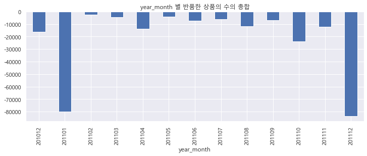

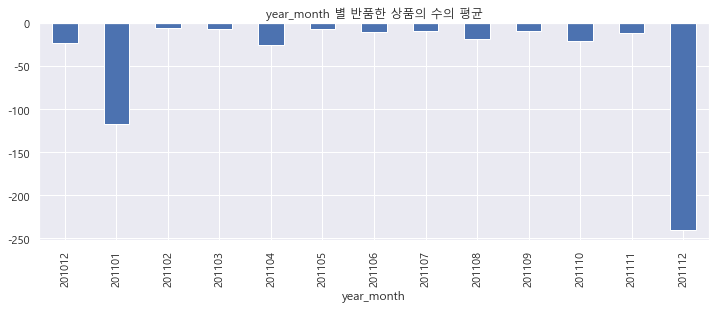

```python
plt.figure(figsize=(12,4))
returned_yearmonth.Quantity.plot(kind = "bar");
plt.title('year_month 별 반품한 상품의 수의 총합');

plt.figure(figsize=(12,4))
returned_yearmonth2.Quantity.plot(kind = "bar");
plt.title('year_month 별 반품한 상품의 수의 평균');
```

- year_month 별 반품한 상품의 개수는 그 평균과 총합이 비슷한 양상을 보입니다.
- 주로 연말과 연초에 반품량이 많고 반품 총액이 큰 것을 확인할 수 있습니다.

"year_month" 별로 반품 상품의 금액 알아보기

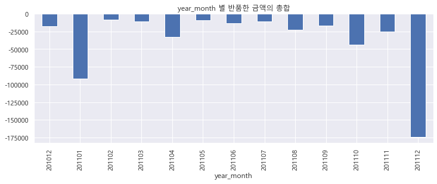

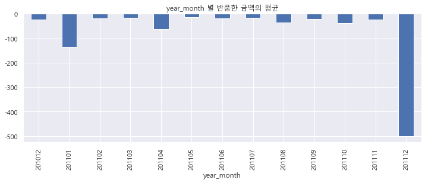

```python
plt.figure(figsize=(12,4))
returned_yearmonth.TrAmount.plot(kind = "bar");
plt.title('year_month 별 반품한 금액의 총합');

plt.figure(figsize=(12,4))
returned_yearmonth2.TrAmount.plot(kind = "bar");
plt.title('year_month 별 반품한 금액의 평균');
```

- 위와 마찬가지로 year_month 별 반품한 금액의 총합과 평균에는 큰 차이가 없습니다.
- 한편 금액에서는 2011년 12월이 1월보다 현저히 높은 것을 알 수 있습니다.

#### month

"month" 별로 반품 개수 알아보기

```python
returned_month = returned_df.groupby("month").sum()
returned_month2 = returned_df.groupby("month").mean()
```

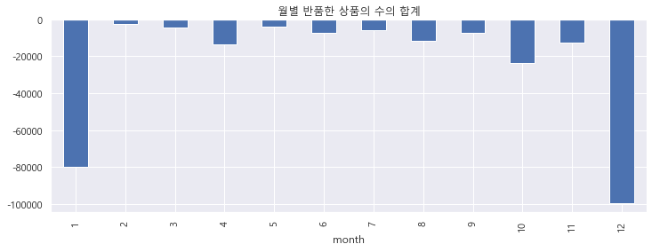

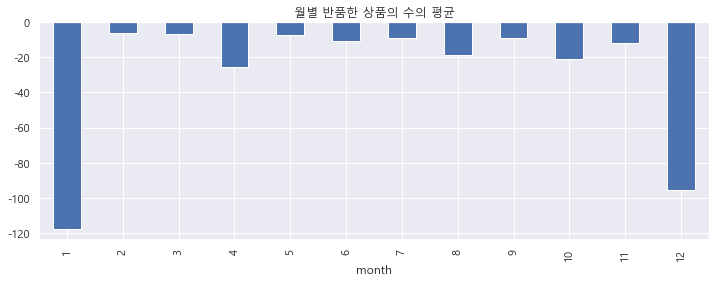

```python
plt.figure(figsize=(12,4))
returned_month.Quantity.plot(kind = "bar");
plt.title('월별 반품한 상품의 수의 합계');

plt.figure(figsize=(12,4))
returned_month2.Quantity.plot(kind = "bar");
plt.title('월별 반품한 상품의 수의 평균');
```

- 대체적으로 1월과 12월에 반품이 많은 것으로 확인됩니다.
- 개수의 총합은 12월 > 1월 이지만 평균은 12월 < 1월 입니다.

```python
returned_df.month.value_counts()
```

```
10    1126
12    1046
11    1016
9      760
1      679
6      669
3      642
7      642
8      617
5      558
4      531
2      418
Name: month, dtype: int64
```

"month" 별로 반품 상품의 금액 알아보기

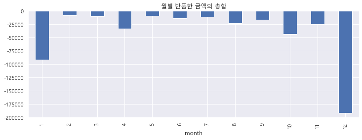

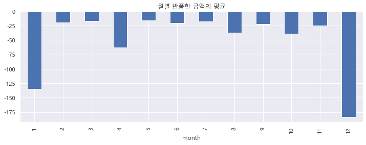

```python
plt.figure(figsize=(12,4))
returned_month.TrAmount.plot(kind = "bar");
plt.title('월별 반품한 금액의 총합');

plt.figure(figsize=(12,4))
returned_month2.TrAmount.plot(kind = "bar");
plt.title('월별 반품한 금액의 평균');
```

- 금액에서는 총합과 평균의 양상에 큰 차이가 없습니다.

#### day

"day" 별로 반품 개수 알아보기

```python
returned_day = returned_df.groupby("day").sum()
returned_day2 = returned_df.groupby("day").mean()
# dayofweek 월요일1 ~ 일요일7
```

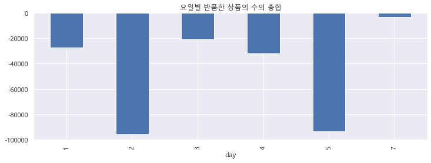

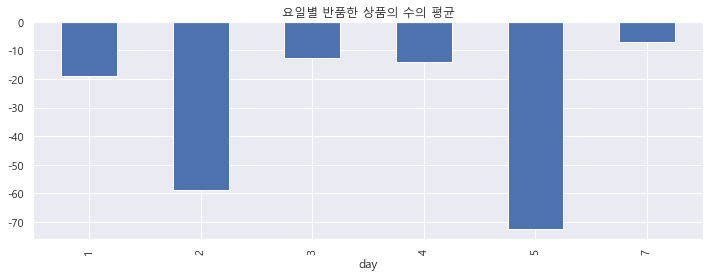

```python
plt.figure(figsize=(12,4))
returned_day.Quantity.plot(kind = "bar");
plt.title('요일별 반품한 상품의 수의 총합');

plt.figure(figsize=(12,4))
returned_day2.Quantity.plot(kind = "bar");
plt.title('요일별 반품한 상품의 수의 평균');
```

- 요일별 반품한 상품의 개수는 총합과 평균이 비슷한 양상을 보입니다.
- 대체로 화요일(2), 금요일(5)에 반품한 상품의 수가 많습니다.
  - 화요일 : 주말에 반품하려다 쉬는 것을 깨닫고 평일에 반품하려 했으나 까먹어서 화요일에 반품
  - 금요일 : 주말이 되면 반품하기 어려우므로 금요일, 주말이 오기 전에 빨리 반품

  위와 같이 유추해 볼 수 있습니다.
- 토요일(6)에 반품한 상품은 없습니다.
- 일요일(7)에 반품한 상품이 최소입니다.
- 주말엔 대부분의 CS 센터가 휴무이므로 주말에 가장 적은 수치가 나타난 것으로 보입니다.

```python
returned_df.day.value_counts()
```

```
4    2248
3    1649
2    1631
1    1434
5    1290
7     452
Name: day, dtype: int64
```

"day" 별로 반품 상품의 금액 알아보기

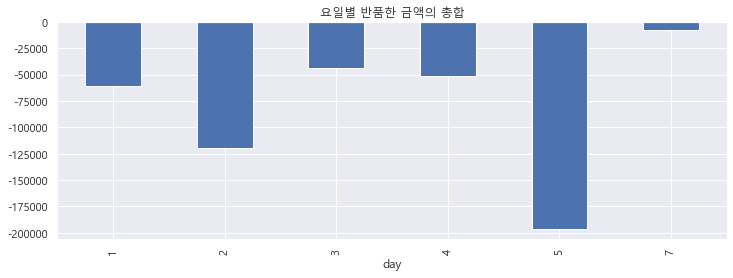

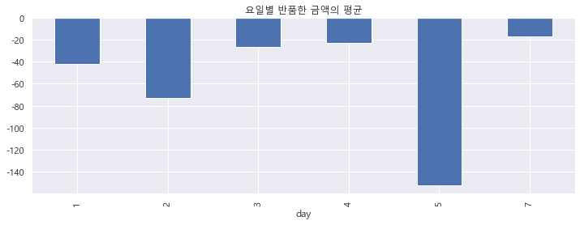

```python
plt.figure(figsize=(12,4))
returned_day.TrAmount.plot(kind = "bar");
plt.title('요일별 반품한 금액의 총합');

plt.figure(figsize=(12,4))
returned_day2.TrAmount.plot(kind = "bar");
plt.title('요일별 반품한 금액의 평균');
```

#### hour

"hour" 별로 반품 개수 알아보기

```python
returned_hour = returned_df.groupby("hour").sum()
returned_hour2 = returned_df.groupby("hour").mean()
```

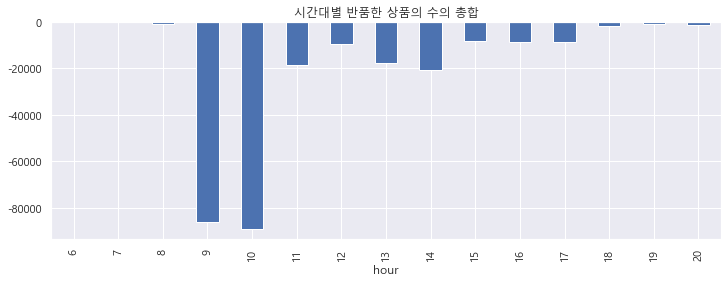

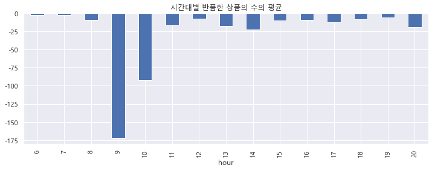

```python
plt.figure(figsize=(12,4))
returned_hour.Quantity.plot(kind = "bar");
plt.title('시간대별 반품한 상품의 수의 총합');

plt.figure(figsize=(12,4))
returned_hour2.Quantity.plot(kind = "bar");
plt.title('시간대별 반품한 상품의 수의 평균');
```

- 반품한 상품의 수의 합계와 평균 모두 9시와 10시에 반품한 상품의 수가 많습니다.
- 보통의 CS 센터들이 9시~5시의 운영시간을 가지고 있으므로  
  9시, CS 센터 오픈하자마자 반품을 많이 하는 것으로 보이고  
  같은 이유로 6시 이후에는 반품하는 상품의 수가 현저히 적은 것으로 파악됩니다. (합계 그래프 참고)

"hour" 별로 반품 상품의 금액 알아보기

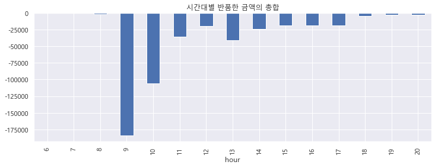

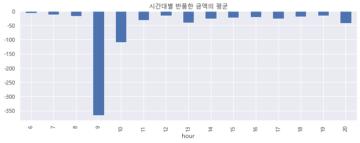

```python
plt.figure(figsize=(12,4))
returned_hour.TrAmount.plot(kind = "bar");
plt.title('시간대별 반품한 금액의 총합');

plt.figure(figsize=(12,4))
returned_hour2.TrAmount.plot(kind = "bar");
plt.title('시간대별 반품한 금액의 평균');
```

- 위의 상품의 수는 9시 ~ 10시에 최대인 것으로 나타난 것과 마찬가지로 상품 금액도 9시 ~ 10시에 최대인 것으로 나타납니다.
- 즉, 9시에는 반품하는 상품의 수도 많고 그 금액도 최대입니다.  
  10시에 반품되는 상품들은 개수가 많지만 그 단가가 저렴한 것으로 보입니다.

종합해보면

- 연말, 연초 (1월, 12월)
- 화요일, 금요일
- 9~10시  
  에 반품되는 상품이 많다고 할 수 있습니다.

### 상품별 분석

```python
returned_product = returned_df.groupby("Description").sum().sort_values(by = "Quantity")
returned_product.head(10)
```

| Description | Quantity | UnitPrice | TrAmount | year_month | month | day | hour |
| --- | --- | --- | --- | --- | --- | --- | --- |
| PAPER CRAFT , LITTLE BIRDIE | -80995 | 2.08 | -168469.60 | 201112 | 12 | 5 | 9 |
| MEDIUM CERAMIC TOP STORAGE JAR | -74494 | 11.66 | -77479.64 | 2011073 | 73 | 28 | 129 |
| ROTATING SILVER ANGELS T-LIGHT HLDR | -9376 | 7.68 | -321.60 | 804235 | 35 | 9 | 49 |
| FAIRY CAKE FLANNEL ASSORTED COLOUR | -3150 | 4.99 | -6591.42 | 603327 | 27 | 7 | 41 |
| PINK BLUE FELT CRAFT TRINKET BOX | -2617 | 5.87 | -2778.77 | 1005531 | 31 | 15 | 64 |
| WHITE HANGING HEART T-LIGHT HOLDER | -2578 | 117.90 | -6624.30 | 8445882 | 282 | 116 | 545 |
| GIN + TONIC DIET METAL SIGN | -2030 | 15.98 | -3775.33 | 1407651 | 51 | 18 | 97 |
| HERB MARKER BASIL | -1527 | 1.20 | -841.05 | 402213 | 13 | 5 | 22 |
| FELTCRAFT DOLL MOLLY | -1447 | 16.65 | -3512.65 | 1206557 | 57 | 19 | 75 |
| TEA TIME PARTY BUNTING | -1424 | 25.30 | -3692.95 | 1407734 | 34 | 20 | 82 |

```python
returned_product2 = returned_df.groupby("Description").mean().sort_values(by = "Quantity")
returned_product2.head(10)
```

| Description | Quantity | UnitPrice | TrAmount | year_month | month | day | hour |
| --- | --- | --- | --- | --- | --- | --- | --- |
| PAPER CRAFT , LITTLE BIRDIE | -80995.00 | 2.080000 | -168469.6000 | 201112.00 | 12.00 | 5.000000 | 9.000000 |
| MEDIUM CERAMIC TOP STORAGE JAR | -7449.40 | 1.166000 | -7747.9640 | 201107.30 | 7.30 | 2.800000 | 12.900000 |
| ROTATING SILVER ANGELS T-LIGHT HLDR | -2344.00 | 1.920000 | -80.4000 | 201058.75 | 8.75 | 2.250000 | 12.250000 |
| FAIRY CAKE FLANNEL ASSORTED COLOUR | -1050.00 | 1.663333 | -2197.1400 | 201109.00 | 9.00 | 2.333333 | 13.666667 |
| HERB MARKER BASIL | -763.50 | 0.600000 | -420.5250 | 201106.50 | 6.50 | 2.500000 | 11.000000 |
| MIRROR MOSAIC T-LIGHT HOLDER | -720.00 | 0.390000 | -280.8000 | 201110.00 | 10.00 | 1.000000 | 10.000000 |
| VINTAGE BILLBOARD TEA MUG | -701.00 | 1.060000 | -743.0600 | 201108.00 | 8.00 | 3.000000 | 15.000000 |
| PINK BLUE FELT CRAFT TRINKET BOX | -523.40 | 1.174000 | -555.7540 | 201106.20 | 6.20 | 3.000000 | 12.800000 |
| BASKET OF TOADSTOOLS | -408.00 | 1.060000 | -432.4800 | 201107.00 | 7.00 | 4.000000 | 17.000000 |
| PAPER POCKET TRAVELING FAN | -346.25 | 0.105000 | -27.0725 | 201108.75 | 8.75 | 3.250000 | 14.500000 |

[반품량 감소 방안]

가장 반품량이 많은 PAPER CRAFT , LITTLE BIRDIE, MEDIUM CERAMIC TOP STORAGE JAR, ROTATING SILVER ANGELS T-LIGHT HLDR 은 모두 재질이 약하기 때문에 불량이나 운송과정에서의 손상이 빈번하게 발생합니다.  
따라서 제작 및 운송 과정에 유의하고 보다 안전한 포장을 통해 손상을 최소화한다면 반품량이 줄 것으로 예상됩니다.

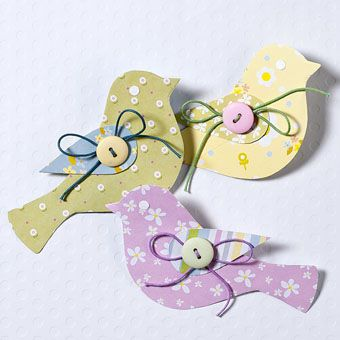

PAPER CRAFT , LITTLE BIRDIE,

[figure not shown]

MEDIUM CERAMIC TOP STORAGE JAR

[figure not shown]

ROTATING SILVER ANGELS T-LIGHT HLDR